# Hands-On Session: Datenbereinigung mit R

Zoé Wolter

Nov 25, 2021

## Packages laden

Im ersten Schritt solltet Ihr immer alle Packages laden, die Ihr für Euren Code benötigt. Am Übersichtlichsten ist es meistens, wenn Ihr ein separates R-Skript anlegt, um die Packages zu installieren bzw. zu laden, in diesem Fall könnt Ihr das einfach direkt hier im Rmd machen:

```r
library(tidyverse)
```

## Die Daten

### Daten einlesen

Für diese Hands-On Session werdet Ihr Euch Daten der Stadt Konstanz zur Fahrradzählung im Stadtgebiet am Herosé-Park im Jahr 2020 anschauen. Ladet dafür die Daten, welche Ihr auf folgender Website findet: https://offenedaten-konstanz.de/dataset/dauerz-hlstellen-radverkehr/resource/c7da262a-7f4e-41a4-9a57-1d41222d77a4#{}. Hint: Ihr könnt Euch die Daten entweder downloaden und dann einlesen oder die Daten einfach direkt über die URL zum .csv-Datensatz einlesen. Egal wie, achtet auf das Zeichen zur Trennung von Spalten!

```r
readr::read_delim('https://offenedaten-konstanz.de/sites/default/files/Z%C3%A4hlstelle_Heros%C3%A9_2020_Wetter_st%C3%BCndlich.csv', delim = ";", escape_double = FALSE, trim_ws = TRUE) -> bikes
```

### Ein erster Überblick

Wenn Ihr die Daten eingelesen habt, solltet Ihr Euch zuerst einen Überblick über die Variablen, ihren Typ und den Umfang des Datensatzes verschaffen.

Variablen:

- Zeit: Datum (DD.MM.JJJJ)
- Uhrzeit (HH:MM)
- Fahrradbruecke: Anzahl RadverkehrsteilnehmerInnen gesamt (Zahl)
- Fahrradbruecke stadteinwaerts: Anzahl RadverkehrsteilnehmerInnen stadteinwärts (Zahl) (linksrheinisches Gebiet)
- Fahrradbruecke stadtauswaerts: Anzahl RadverkehrsteilnehmerInnen stadtauswärts (Zahl)
- Symbol Wetter: Kategorisierung Wetter
- Temperatur: Gemessene Temperatur zum gemessenen Zeitpunkt in Grad Celsius
- Gefühlte Temperatur: Wahrgenommene Umgebungstemperatur, nach dem Hitzindex gemessene gefühlte Temperatur zum gemessenen Zeitpunkt in Grad Celsius
- Regen (mm): Niederschlag zum Zeitpunkt in Millimeter

```r
# Wie viele Variablen sind im Datensatz?
bikes %>%
  ncol()
```

```
## [1] 8
```

```r
# Wie sind die oben gelisteten Variablen benannt?
bikes %>%
  names()
```

```
## [1] "Zeit"
## [2] "FahrradbrueckeFahrradbruecke"
## [3] "FahrradbrueckeFahrradbruecke stadteinwärts Fahrräder"
## [4] "FahrradbrueckeFahrradbruecke stadtauswärts Fahrräder"
## [5] "Symbol Wetter"
## [6] "Temperatur (°C)"
## [7] "Gefühlte Temperatur (°C)"
## [8] "Regen (mm)"
```

```r
# Wie viele Beobachtungen bzw. sind im Datensatz?
bikes %>%
  nrow()
```

```
## [1] 8785
```

```r
# Lasst Euch die ersten fünf Zeilen des Datensatzes anzeigen!
bikes %>%
  head()
```

```
## # A tibble: 6 x 8
##   Zeit   FahrradbrueckeFa~ `FahrradbrueckeFa~ `FahrradbrueckeFa~ `Symbol Wetter`
##   <chr>              <dbl>              <dbl>              <dbl> <chr>
## 1 01.01~               104                 31                 73 Leicht bewölkt
## 2 01.01~               128                 47                 81 Leicht bewölkt
## 3 01.01~               178                 77                101 Sonnig
## 4 01.01~               113                 56                 57 Sonnig
## 5 01.01~                76                 36                 40 Sonnig
## 6 01.01~                50                 12                 38 Sonnig
## # ... with 3 more variables: Temperatur (°C) <dbl>,
## #   Gefühlte Temperatur (°C) <dbl>, Regen (mm) <dbl>
```

```r
# Welchen Datentyp haben die Variablen aktuell? Ist dieser sinnvoll?
bikes %>%
  summary()
```

```
##      Zeit           FahrradbrueckeFahrradbruecke
##  Length:8785        Min.   :   0.0
##  Class :character   1st Qu.:  53.0
##  Mode  :character   Median : 250.0
##                     Mean   : 336.8
##                     3rd Qu.: 559.0
##                     Max.   :1500.0
##                     NA's   :1
##  FahrradbrueckeFahrradbruecke stadteinwärts Fahrräder
##  Min.   :  0.0
##  1st Qu.: 25.0
##  Median :119.0
##  Mean   :165.3
##  3rd Qu.:275.0
##  Max.   :808.0
##  NA's   :1
##  FahrradbrueckeFahrradbruecke stadtauswärts Fahrräder Symbol Wetter
##  Min.   :  0.0                                        Length:8785
##  1st Qu.: 28.0                                        Class :character
##  Median :129.0                                        Mode  :character
##  Mean   :171.5
##  3rd Qu.:278.0
##  Max.   :876.0
##  NA's   :1
##  Temperatur (°C) Gefühlte Temperatur (°C)   Regen (mm)
##  Min.   :-6.00   Min.   :-9.00            Min.   : 0.000
##  1st Qu.: 4.00   1st Qu.: 3.00            1st Qu.: 0.000
##  Median :10.00   Median : 9.00            Median : 0.000
##  Mean   :10.22   Mean   : 9.56            Mean   : 1.534
##  3rd Qu.:16.00   3rd Qu.:16.00            3rd Qu.: 1.000
##  Max.   :32.00   Max.   :34.00            Max.   :71.000
##  NA's   :1       NA's   :1                NA's   :1
```

```r
bikes %>%
  lapply(class)
```

```
## $Zeit
## [1] "character"
##
## $FahrradbrueckeFahrradbruecke
## [1] "numeric"
##
## $`FahrradbrueckeFahrradbruecke stadteinwärts Fahrräder`
## [1] "numeric"
##
## $`FahrradbrueckeFahrradbruecke stadtauswärts Fahrräder`
## [1] "numeric"
##
## $`Symbol Wetter`
## [1] "character"
##
## $`Temperatur (°C)`
## [1] "numeric"
##
## $`Gefühlte Temperatur (°C)`
## [1] "numeric"
##
## $`Regen (mm)`
## [1] "numeric"
```

## Datenbereinigung

Nachdem Ihr mit dem Datensatz nun etwas vertrauter seid, könnt Ihr Euch nun an die eigentliche Arbeit, die Datenbereinigung machen. Dabei schaut Ihr Euch nebenbei die `dplyr`-Verben noch einmal genauer an.

### Die Funktion `dplyr::select`

Wählt zunächst folgende Variablen aus und benennt sie entsprechend um:

- Zeit = datetime
- FahrradbrueckeFahrradbruecke stadteinwärts Fahrräder = bikes_into_town
- FahrradbrueckeFahrradbruecke stadtauswärts Fahrräder = bikes_out_of_town
- Symbol Wetter = weather
- Temperatur (°C) = temperature
- Regen (mm) = rain

```r
bikes %>%
  dplyr::select(
    datetime = 'Zeit',
    bikes_into_town = 'FahrradbrueckeFahrradbruecke stadteinwärts Fahrräder',
    bikes_out_of_town = 'FahrradbrueckeFahrradbruecke stadtauswärts Fahrräder',
    weather = 'Symbol Wetter',
    temperature = 'Temperatur (°C)',
    rain = 'Regen (mm)'
  ) -> bikes
```

Nachdem Ihr nun nur die für Euch relevanten Variablen noch im Datensatz habt, weist Ihnen den angegebenen Datentyp zu. Hint: Macht Euch nicht zu viel Arbeit und schaut, welche Variablen bereits den richtigen Datentyp haben!

- datetime = datetime (Hint: Googelt mal das R-Package `lubridate`!)
- bikes_into_town = numeric
- bikes_out_of_town = numeric
- weather = factor
- temperature = numeric
- rain = numeric

```r
# Überprüfe Variablentyp
bikes %>%
  lapply(class)
```

```
## $datetime
## [1] "character"
##
## $bikes_into_town
## [1] "numeric"
##
## $bikes_out_of_town
## [1] "numeric"
##
## $weather
## [1] "character"
##
## $temperature
## [1] "numeric"
##
## $rain
## [1] "numeric"
```

```r
# datetime
bikes$datetime %>%
  lubridate::dmy_hm() -> bikes$datetime

# weather
bikes$weather %>%
  as.factor() -> bikes$weather
bikes$weather %>%
  summary()
```

```
##                                     Bedeckt
##                                         555
##                                     Bewölkt
##                                         323
##                              Leicht bewölkt
##                                        4377
##                            Leichte Eisregen
##                                          12
##                       Leichte Schneeschauer
##                                          12
##                           Leichter Eisregen
##                                          45
##                              Leichter Nebel
##                                         214
##                          Leichter Regenfall
##                                         300
##                       Leichter Regenschauer
##                                         360
##                         Leichter Schneefall
##                                          35
##               Mäßige bis starke Schneefälle
##                                          72
##                Mäßiger bis starker Eisregen
##                                           9
##      Mäßiger bis starker gefrierender Regen
##                                           3
##      Mäßiger bis starker Regen mit Gewitter
##                                           9
##            Mäßiger bis starker Regenschauer
##                                         114
## Mäßiger bis starker Schneefall mit Gewitter
##                                           3
##                           Mäßiger Regenfall
##                                         249
##                          Mäßiger Schneefall
##                                          30
##                                       Nebel
##                                           9
##                                 Nieselregen
##                                         234
```

[output cut: 21 more lines]

```
##                                           6
##            Stellenweiser leichter Regenfall
##                                          57
##                   Stellenweiser Nieselregen
##                                          87
##                     Stellenweiser Regenfall
##                                         767
##                    Stellenweiser Schneefall
##                                           6
##                 Teilweise mäßiger Regenfall
##                                          57
##                 Teilweise starker Regenfall
##                                           3
##                      weather_condition_null
##                                           1
```

### Die Funktion `dplyr::arrange`

Sortiert den Datensatz nach der Variable `temperature` absteigend! An welchen Tagen war die Temperatur am höchsten?

```r
# Ihr nehmt Euren Datensatz...
bikes %>%
  # ...und sortiert die Werte absteigend!
  dplyr::arrange(desc(temperature))
```

```
## # A tibble: 8,785 x 6
##    datetime            bikes_into_town bikes_out_of_town weather     temperature
##    <dttm>                        <dbl>             <dbl> <fct>             <dbl>
##  1 2020-08-21 15:00:00             332               379 Leicht bew~          32
##  2 2020-07-31 15:00:00             444               497 Leicht bew~          31
##  3 2020-08-01 15:00:00             321               363 Leicht bew~          31
##  4 2020-08-21 12:00:00             340               385 Leicht bew~          31
##  5 2020-08-21 13:00:00             309               427 Leicht bew~          31
##  6 2020-08-21 14:00:00             334               364 Leicht bew~          31
##  7 2020-08-21 16:00:00             341               365 Leicht bew~          31
##  8 2020-07-31 13:00:00             387               490 Leicht bew~          30
##  9 2020-07-31 14:00:00             455               435 Leicht bew~          30
## 10 2020-07-31 16:00:00             444               454 Leicht bew~          30
## # ... with 8,775 more rows, and 1 more variable: rain <dbl>
```

Sortiert den Datensatz nun nach der Variable `bikes_into_town` absteigend!

```r
# Ihr nehmt Euren Datensatz...
bikes %>%
  # ...und sortiert die Werte absteigend!
  dplyr::arrange(desc(bikes_into_town))
```

```
## # A tibble: 8,785 x 6
##    datetime            bikes_into_town bikes_out_of_town weather     temperature
##    <dttm>                        <dbl>             <dbl> <fct>             <dbl>
##  1 2020-09-17 07:00:00             808               439 Leicht bew~          15
##  2 2020-09-22 07:00:00             804               413 Stellenwei~          14
##  3 2020-09-16 07:00:00             794               413 Leicht bew~          17
##  4 2020-09-18 07:00:00             777               371 Leichter N~          14
##  5 2020-09-23 07:00:00             768               435 Nieselregen          15
##  6 2020-09-21 07:00:00             767               430 Leicht bew~          14
##  7 2020-09-15 07:00:00             765               421 Leicht bew~          17
##  8 2020-09-14 09:00:00             738               294 Leichter N~          19
##  9 2020-09-28 07:00:00             725               365 Leichter N~           5
## 10 2020-09-30 07:00:00             720               383 Leicht bew~           9
## # ... with 8,775 more rows, and 1 more variable: rain <dbl>
```

### Die Funktion `dplyr::filter`

Erstellt nun die beiden Datensätze `bikes_sunny` und `bikes_rainy`:

`bikes_sunny` für folgendes Wetter: - Sonnig `bikes_rainy` für folgendes Wetter: - Leichter Regenfall - Leichter Regenschauer - Mäßiger bis starker Regenschauer - Mäßiger Regenfall - Nieselregen - Sintflutartiger Regenfall - Starker Regenfall - Stellenweiser leichter Regenfall - Stellenweiser Nieselregen - Stellenweiser Regenfall - Teilweise mäßiger Regenfall - Teilweise starker Regenfall

```r
# Datensatz bikes_sunny
bikes %>%
  dplyr::filter(
    .$weather == 'Sonnig'
  ) -> bikes_sunny

# Datensatz bikes_rainy
bikes %>%
  dplyr::filter(
    .$weather %in% c(
      'Leichter Regenfall',
      'Leichter Regenschauer',
      'Mäßiger bis starker Regenschauer',
      'Mäßiger Regenfall',
      'Nieselregen',
      'Sintflutartiger Regenfall',
      'Starker Regenfall',
      'Stellenweiser leichter Regenfall',
      'Stellenweiser Nieselregen',
      'Stellenweiser Regenfall',
      'Teilweise mäßiger Regenfall',
      'Teilweise starker Regenfall'
    )
  ) -> bikes_rainy
```

### Die Funktion `dplyr::mutate`

Bisher habt Ihr eine Variable für den Tag und die Uhrzeit zusammen im Datensatz `bikes`. Erstellt aus der Variable `datetime` nun zwei unterschiedliche Variablen `day` und `time`:

```r
bikes %>%
  dplyr::mutate(
    day = as.Date(datetime),
    time = format(as.POSIXct(datetime), format = "%H:%M:%S")
  ) -> bikes
```

### Die Funktionen `dplyr::group_by` und `dplyr::summarize`

Nutzt nun die Funktionen `group_by` und `summarize` aus dem `dplyr`-Package, um den Datensatz `bikes` nach Tagen zu gruppieren und dann folgende Kennwerte für die anderen Variablen zu erstellen:

- Summe für `bikes_into_town`
- Summe für `bikes_out_of_town`
- Mittelwert für `temperature`
- Summe für `rain`

Hint: Achtet dabei besonders auf den Umgang mit NA’s!

```r
bikes %>%
  dplyr::group_by(day) %>%
  dplyr::summarize(bikes_into_town = sum(bikes_into_town, na.rm = TRUE),
                   bikes_out_of_town = sum(bikes_out_of_town, na.rm = TRUE),
                   temperature = mean(temperature, na.rm = TRUE),
                   rain = sum(rain, na.rm = TRUE)) -> bikes
```

### Pivoting

Nun habt Ihr pro Tag eine Variable zu den Fahrradfahrern die Stadt und aus der Stadt. Die Daten sind also im wide-Format. Bringt diese nun ins long-Format, sodass Ihr nur noch eine Variable mit der Anzahl an Fahrrädern habt und in einer separaten Spalte die Information zur Richtung:

```r
bikes %>%
  tidyr::pivot_longer(cols = c(bikes_into_town, bikes_out_of_town),
                      names_to = 'direction',
                      values_to = 'bikes') -> bikes
```

## Finale Visualisierung

And finally… Wenn Ihr die Datenbereinigung oben so durchgeführt habt, wie es beschrieben war, dann solltet Ihr folgenden Code nun ausführen können und eine schöne abschließende Visualisierung erhalten - habt Ihr richtig gut gemacht! Kleiner Teaser: Zum Thema Datenvisualisierung wird es bald auch einen CorrelAid-Workshop geben - schaut dafür gerne auf unserer [Website](https://correlaid.github.io/correlaidx-kn-education/) vorbei!

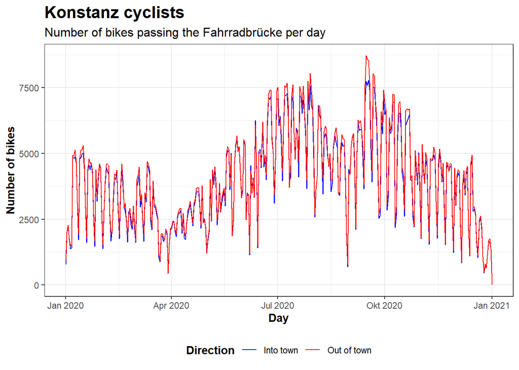

```r
bikes %>%
  ggplot2::ggplot(aes(x = day, y = bikes, color = direction)) +
  ggplot2::geom_line() +
  ggplot2::theme_bw() +
  ggplot2::labs(title = 'Konstanz cyclists',
                subtitle = 'Number of bikes passing the Fahrradbrücke per day',
                x = 'Day',
                y = 'Number of bikes') +
  ggplot2::scale_color_manual(name = 'Direction',
                              labels = c('Into town', 'Out of town'),
                              values = c('blue', 'red')) +
  ggplot2::theme(plot.title = element_text(size = 16, face = 'bold'),
                 plot.subtitle = element_text(size = 12),
                 legend.title = element_text(face = 'bold'),
                 axis.title = element_text(face = 'bold'),
                 legend.position = 'bottom')
```